# Projekt z eksploracji danych

Klasyfikacja zainteresowania klienta założeniem lokaty terminowej

Diana Morzhak

# 1 Problem predykcyjny oraz charakterystyka analizowanego zbioru danych

Lokata terminowa jest produktem bankowym polegającym na zdeponowaniu środków na z góry określony czas, zwykle w zamian za ustalone oprocentowanie. W praktyce klient akceptuje ograniczoną dostępność pieniędzy w okresie trwania lokaty, a bank może przewidywać, jak długo będzie dysponował tym kapitałem.

Analizowany zbiór danych dotyczy kampanii telemarketingowej portugalskiej instytucji bankowej. Problem danych polega na wykorzystaniu informacji o kliencie, historii kontaktów oraz kontekście społeczno-ekonomicznym do oceny, czy dana osoba założy lokatę terminową. Problem predykcyjny jest klasyfikacją binarną: zmienna wynikowa `y` przyjmuje wartości `yes` albo `no`, czyli informuje, czy klient podpisał umowę lokaty.

Poniższa tabela przedstawia słownik zmiennych wykorzystanych w zbiorze danych.

| Zmienna | Typ | Przyjmowane wartości / zakres | Znaczenie praktyczne |
| --- | --- | --- | --- |
| `age` | numeryczna | wiek klienta w latach | Wiek klienta kontaktowanego w kampanii. |
| `job` | jakościowa | `admin.`, `blue-collar`, `entrepreneur`, `housemaid`, `management`, `retired`, `self-employed`, `services`, `student`, `technician`, `unemployed`, `unknown` | Typ wykonywanej pracy. |
| `marital` | jakościowa | `divorced`, `married`, `single`, `unknown` | Status cywilny; `divorced` obejmuje osoby rozwiedzione i owdowiałe. |
| `education` | jakościowa | `basic.4y`, `basic.6y`, `basic.9y`, `high.school`, `illiterate`, `professional.course`, `university.degree`, `unknown` | Poziom wykształcenia klienta. |
| `default` | jakościowa | `no`, `yes`, `unknown` | Informacja, czy klient ma niespłacone zobowiązanie kredytowe. |
| `housing` | jakościowa | `no`, `yes`, `unknown` | Informacja, czy klient ma kredyt mieszkaniowy. |
| `loan` | jakościowa | `no`, `yes`, `unknown` | Informacja, czy klient ma kredyt osobisty. |
| `contact` | jakościowa | `cellular`, `telephone` | Typ kanału kontaktu z klientem. |
| `month` | jakościowa | miesiące od `mar` do `dec` występujące w danych | Miesiąc ostatniego kontaktu w bieżącej kampanii. |
| `day_of_week` | jakościowa | `mon`, `tue`, `wed`, `thu`, `fri` | Dzień tygodnia ostatniego kontaktu. |
| `duration` | numeryczna | czas w sekundach | Czas trwania ostatniej rozmowy; zmienna dostępna dopiero po kontakcie. |
| `campaign` | numeryczna | liczba kontaktów w bieżącej kampanii | Liczba kontaktów wykonanych dla klienta w ramach bieżącej kampanii. |
| `pdays` | numeryczna | liczba dni; `999` oznacza brak wcześniejszego kontaktu | Liczba dni od ostatniego kontaktu w poprzedniej kampanii. |
| `previous` | numeryczna | liczba wcześniejszych kontaktów | Liczba kontaktów przed bieżącą kampanią. |
| `poutcome` | jakościowa | `failure`, `nonexistent`, `success` | Wynik poprzedniej kampanii marketingowej. |
| `emp.var.rate` | numeryczna | wskaźnik kwartalny | Wskaźnik zmienności zatrudnienia. |
| `cons.price.idx` | numeryczna | wskaźnik miesięczny | Indeks cen konsumpcyjnych. |
| `cons.conf.idx` | numeryczna | wskaźnik miesięczny | Indeks zaufania konsumentów. |
| `euribor3m` | numeryczna | dzienny wskaźnik procentowy | Trzymiesięczna stopa Euribor. |
| `nr.employed` | numeryczna | wskaźnik kwartalny | Liczba zatrudnionych w gospodarce. |
| `y` | jakościowa binarna | `yes`, `no` | Informacja, czy klient założył lokatę terminową. |

## 1.1 Eksploracyjna analiza danych

W tej części projektu skupimy się na:

- czyszczeniu danych i wstępnej selekcji cech;
- głębszym scharakteryzowaniu analizowanego zbioru danych;
- wstępnym przygotowaniu danych do budowy dalszych modeli predykcyjnych;
- wizualnej analizie danych, jakie mamy do dyspozycji.

Ze zbioru danych usunięto w pełni zduplikowane wiersze. Było ich łącznie 12. Liczba ta wskazuje na ewentualny błąd podczas wprowadzania danych oraz usunięcie tylu wierszy nie zaburza dalszej analizy.

Następnie odkryto, że brakujące dane były zapisane we wszystkich kolumnach jako `unknown` . Zamieniono te wartości na Not a Value `NA` . Wykryto poniższe udziały procentowe braków:

Podsumowanie zbioru danych wskazuje na to, że nie ma zmiennych, w których mogłyby występować jednowymiarowe obserwacje odstające. Zmienne ciągłe, takie jak `emp.var.rate` , `cons.price.idx` , `cons.conf.idx` , `euribor3m` nie posiadają obserwacji znacząco odbiegających od trzeciego kwartyla, a zatem nie ma konieczności badania jednowymiarowych obserwacji odstających dla nich, również z tego względu, że wahania tych współczynników są powodowane różnymi wydarzeniami na rynku i sytuacją ekonomiczną Portugalii.

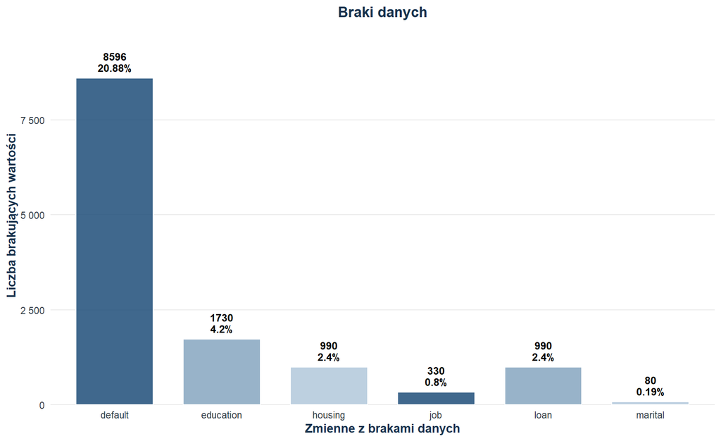

Jak widać, w zbiorze znajduje się dużo zmiennych kategorycznych. Zapoznajmy się z nimi:

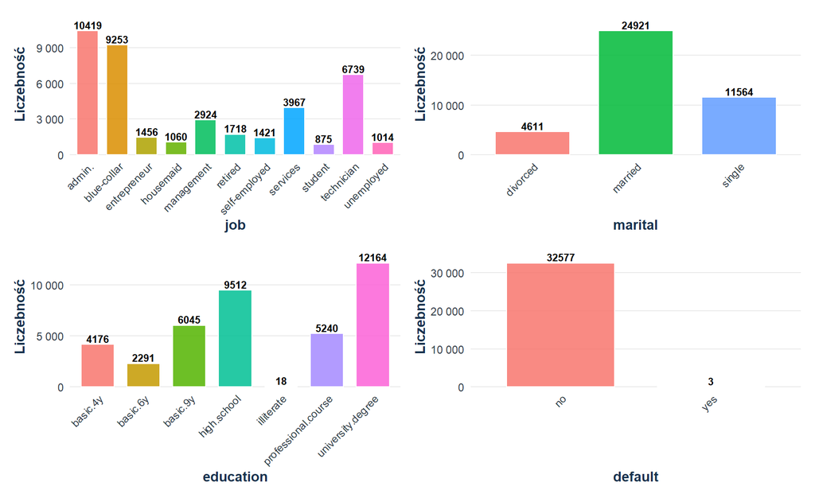

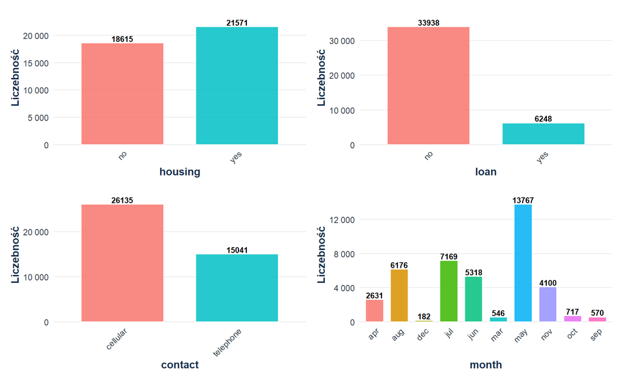

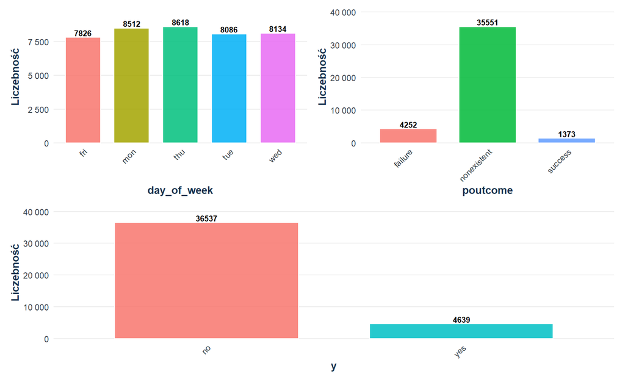

Decydujemy się na usunięcie zmiennej `default`, ponieważ zawiera ekstremalne braki danych, z którymi prawie niemożliwym jest poradzenie sobie próbkowaniem lub under- lub oversamplingiem. Nie jesteśmy w stanie w żaden sposób połączyć wartości zmiennych z innymi kategoriami, ani ich poprawnie imputować. Zmienna `default` jest zmienną near-zero variance.

Podsumowanie wcześniejszych kontaktów z klientami

| Opis | Liczba |
| --- | --- |
| Klienci, z którymi nie kontaktowano się przed obecną kampanią | 35551 |
| Klienci, z którymi nie kontaktowano się poprzednio wcale | 39661 |
| Klienci bez poprzedniego kontaktu i bez kontaktu przed obecną kampanią | 35551 |

Z rozpatrywanego zbioru danych usuwamy również takie zmienne jak `campaign` i `duration`, ponieważ w tej pracy skupiamy się na budowie modeli predykcyjnych, a nie analitycznych. Gdybyśmy zostawili te zmienne, oznaczałoby to, że:

- `campaign` : z góry wiemy, ile razy będziemy kontaktować się z klientem. Natomiast nie posiadamy początkowo takich informacji. Ponadto większa liczba kontaktów może oznaczać pracę z trudniejszym klientem, a mniejsza liczba kontaktów - z klientami, których nie trzeba przekonywać albo poświęcać ponadprzeciętnej ilości czasu, ponieważ, do przykładu, od razu byli zainteresowani wzięciem kredytu. W każdym razie, zostawiając tę zmienną, doprowadzilibyśmy do przecieku danych oraz do posiadania w modelu zmiennej niemożliwej do określenia przed rozpoczęciem kampanii;
- `duration` : mamy bardzo podobną sytuację, ponieważ z reguły osoby zainteresowane kredytem będą dłużej rozmawiać niż osoby nim nie zainteresowane (jak na przykład sami odrzucamy różne oferty od banków, które nas zupełnie nie interesują). Nie są to statystyczne stwierdzenia, a jedynie rozumienie problemu, z którym mamy do czynienia. W tym przypadku bowiem znowu nie posiadamy informacji o długości rozmowy telefonicznej przed rozpoczęciem kampanii, natomiast jeżeli rozmowa ta miała długość trwania 0 sekund, to zmienna wynikowa `y` ma wartość 0, czyli klient nie podpisał umowy o kredyt. W takiej sytuacji znowu mamy do czynienia ze zjawiskiem przecieku danych, czego chcemy uniknąć za wszelką cenę podczas budowy modelu predykcyjnego, jeżeli chcemy móc oceniać jego zdolność do generalizacji.

Dla zmiennej `age` tworzymy biny, aby prognozować podpisanie kredytu uwzględniając poszczególne kategorie wiekowe. Natomiast zmienną `pdays` “rozbijamy” na dwie:

- `was_contacted_before` : wskazuje, czy poprzednio dany klient był kontaktowany. Jest to zmienna kategoryczna i jest krokiem inżynierii cech.
- `clean_pdays` : wskazuje na liczbę dni, które minęły od czasu, gdy skontaktowano się z klientem po raz ostatni. Ma wartość `NA` , gdy z danym klientem nigdy przedtym się nie kontaktowano. Takiej sytuacji nie możemy zakodować jako 0, bo oznaczałoby to, że od ostatniego kontaktu z klientem minęło 0 dni. Żadna liczba całkowita nie odda nam poprawnego charakteru takiej informacji.

  Natomiast sama liczba `pdays` , różna od 999, może wnieść dodatkowe informacje do modelu predykcyjnego, dlatego uwzględniamy `clean_pdays` , a nie samą `was_contacted_before` .

A zatem, obie te zmienne odzwierciedlają poprawne zakodowanie zmiennej `pdays.` Jeżeli mamy brak w zmiennej `clean_pdays` , zmienna `was_contacted_before` wskazuje, że z danym klientem nigdy się nie kontaktowano. W ten sposób obie te zmienne są ze sobą powiązane i skorelowane.

**Campaign**

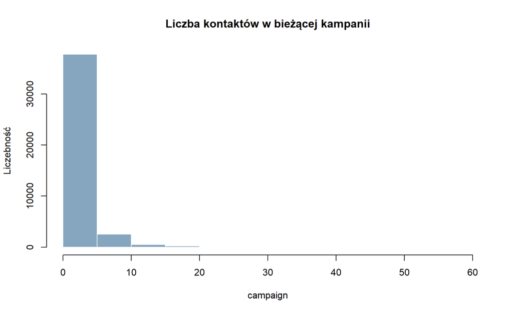

**Previous**

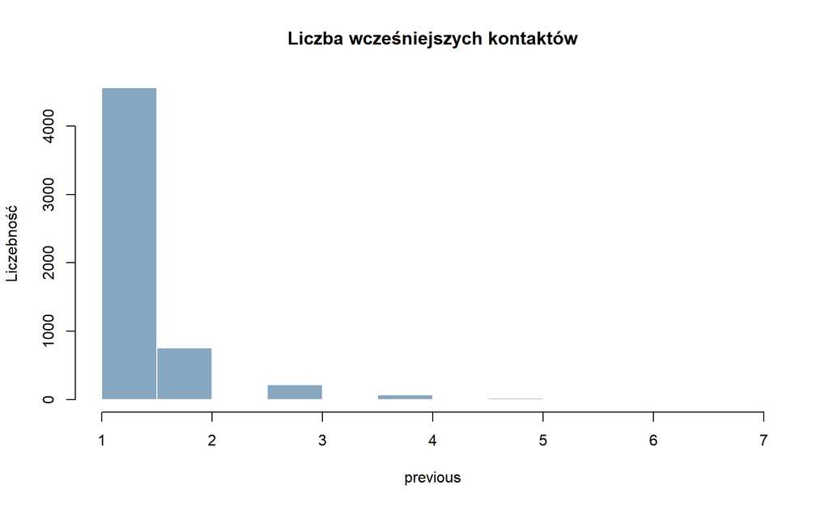

**Pdays**

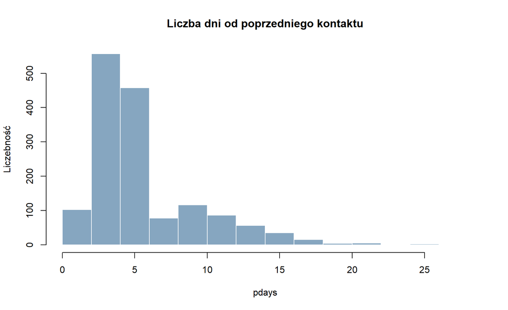

Przekształcamy również zmienną `previous` , by uwzględnić częstość kontaktu z danym klientem w przeszłości. Liczbę powyżej trzech dni łączymy do kategorii 3, która oznacza, że z danym klientem kontaktowano się co najmniej trzy razy w przeszłości przed daną kampanią. Kategoryzujemy tę zmienną ze względu na liczebność poszczególnych prób kontaktu oraz z tego względu, że nowo utworzone kategorie odpowiadają częstości: nigdy (0) -> rzadko (1) -> częściej (2) -> często (3 = 3+).

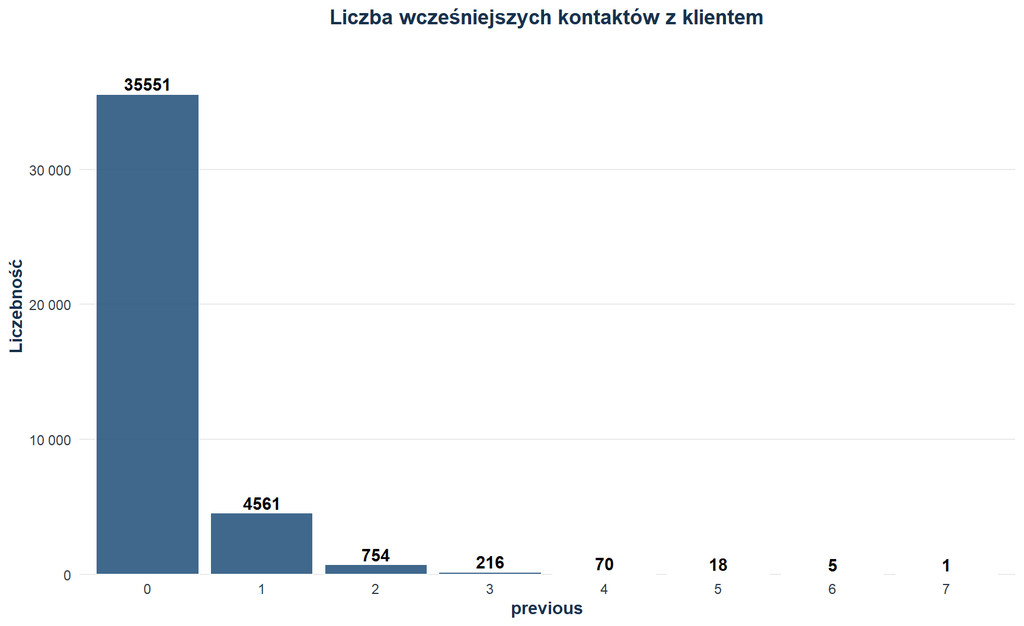

Poniżej znajdują się wykresy wartości poszczególnych zmiennych makroekonomicznych w przeciągu analizowanego okresu:

**Euribor 3M**

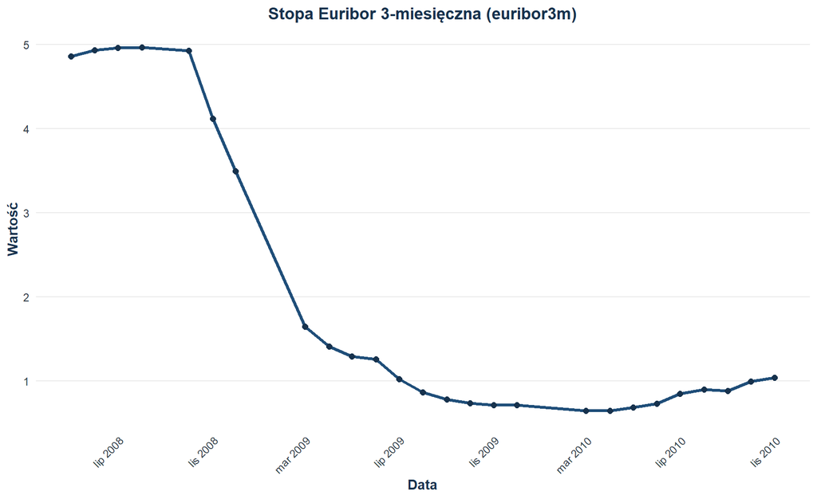

**Zatrudnienie**

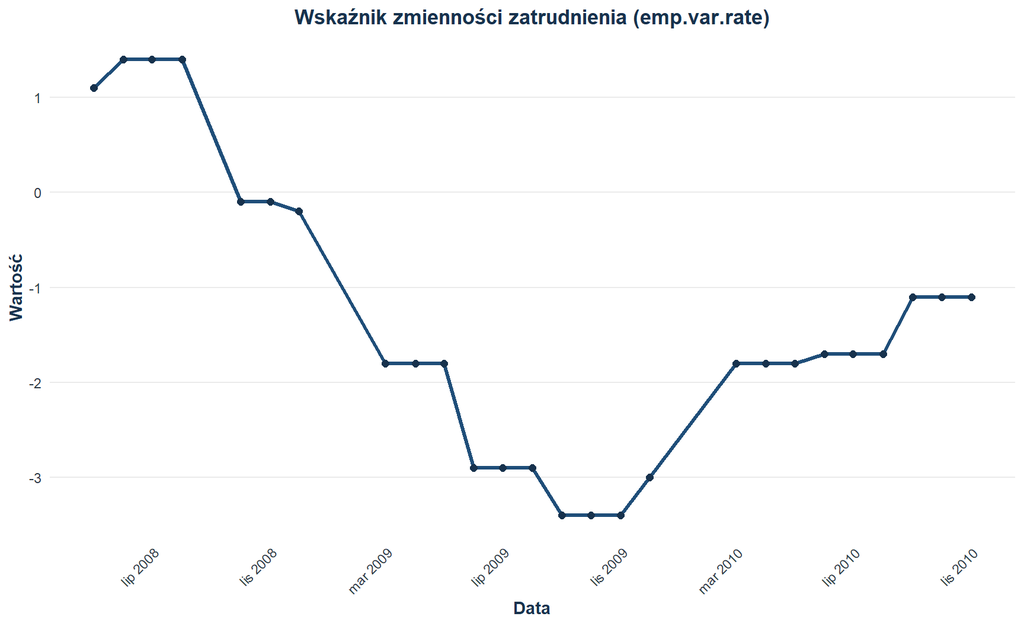

**Ceny**

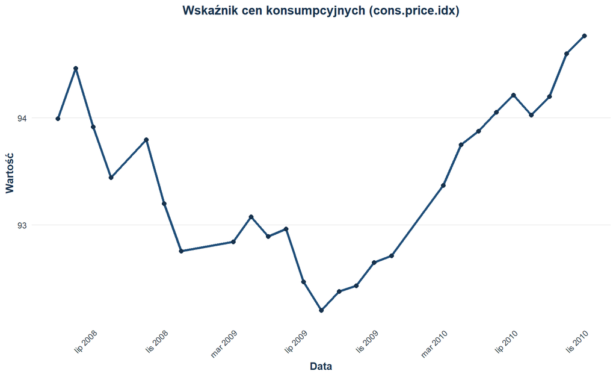

**Ufność**

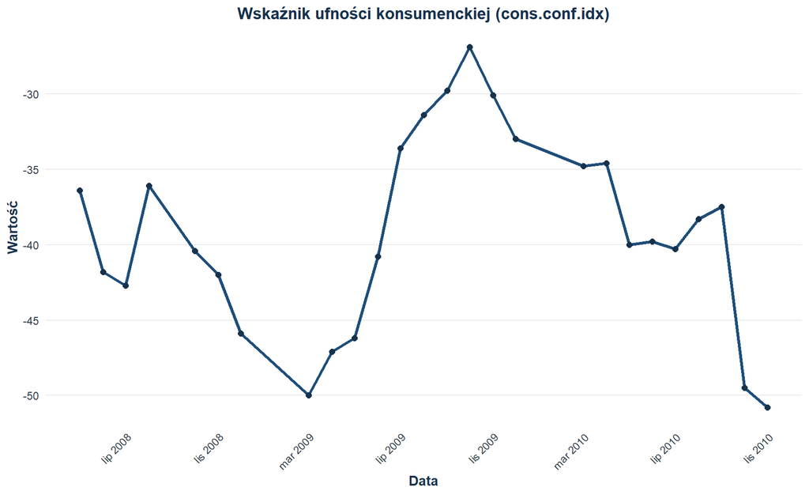

**Liczba pracowników**

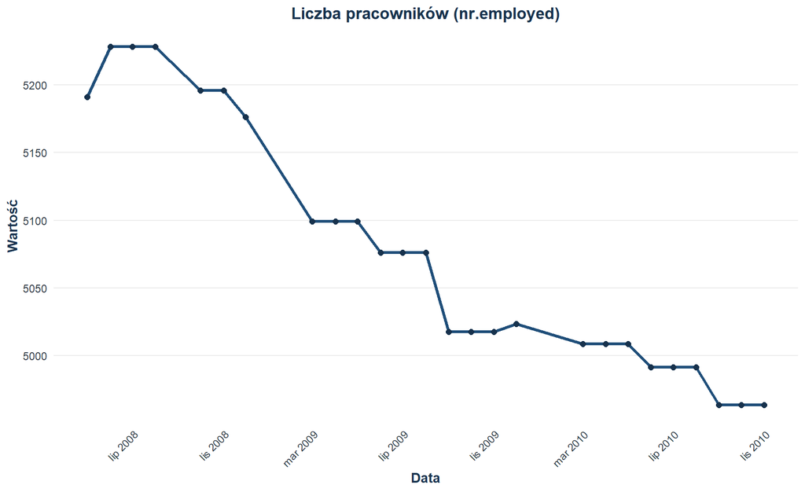

## 1.2 Wielowymiarowe wartości odstające

Wyznaczamy je za pomocą algorytmu lasu izolacyjnego, który pozwala określić wartości odstające również na podstawie zmiennych kategorycznych w odróżnieniu od często stosowanej odległości Mahalanobisa, która poradzi sobie jedynie z wartościami numerycznymi do określenia wielowymiarowych odległości odstających. Skupiamy się od razu na nich, ponieważ po uprzedniej analizie pozostałe zmienne numeryczne nie wykazywały obecności jednowymiarowych wartości odstających. Szczegóły implementacji lasu izolacyjnego można znaleźć w kodzie źródłowym projektu.

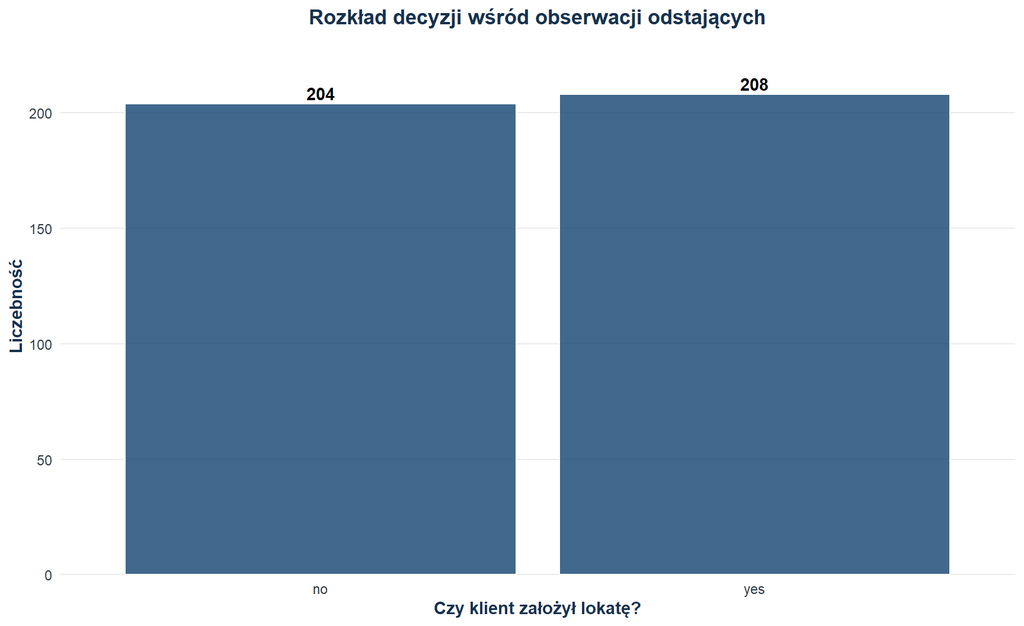

W zbiorze jest 412 wielowymiarowych obserwacji odstających. Wśród nich jest duży udział klientów, którzy wzięli kredyt w banku, na które wskazał algorytm drzewa izolacyjnego. Może to wynikać częściowo z faktu, że obserwacje pozytywnej klasy predykowanej stanowią mniejszość w analizowanym zbiorze danych. Zweryfikujemy teraz, które zmienne wpływają na to, że dana obserwacja jest uznawana za odstającą przez dany algorytm.

### 1.2.1 Wyjaśnienie anomalii

Isolation Forest w wielu wymiarach wyznaczył wartości odstające. Natomiast jak wiedzieć, które kombinacje zmiennych powodują to, że dana obserwacja jest uznawana za odstającą?

W tym celu zbudujemy proste drzewo decyzyjne, które będzie miało za zadanie dokonać predykcji tego, czy dana obserwacja jest obserwacją odstającą. Zbudowane drzewo oraz ważność zmiennych wskaża nam na predyktory anomalii. Nie uwzględniamy w tym kroku zmiennych dotyczących sytuacji gospodarczej ani danych czasowych, ponieważ nie są bezpośrednio związane z danym klientem. W tym kroku analizy chcemy wyłonić nietypowe obserwacje klientów.

Ważność zmiennych w drzewie zastępczym

|  | Variable | Importance |
| --- | --- | --- |
| was_contacted_before | was_contacted_before | 99.06 |
| poutcome | poutcome | 89.77 |
| contact | contact | 75.47 |
| loan | loan | 52.66 |
| age_bin | age_bin | 19.05 |
| job | job | 15.74 |
| previous | previous | 15.43 |
| marital | marital | 2.07 |
| clean_pdays | clean_pdays | 0.21 |

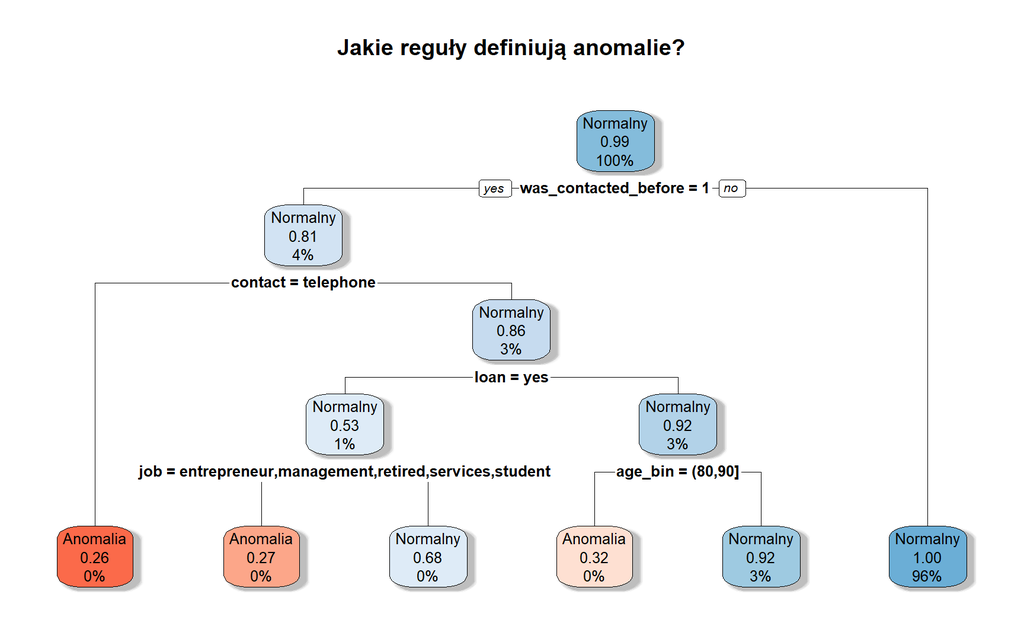

Z powyższego wykresu wynikają następujące reguły anomalii:

1. Osoba, z którą wcześniej się kontaktowano, posługująca się telefonem stacjonarnym - to nie jest dziwny przypadek i możliwym wyjaśnieniem może być skutek rozwoju technologii. Ta grupa osób w zbiorze to jedynie 113 obserwacji;
2. Osoba, z którą wcześniej się kontaktowano, posługująca się telefonem komórkowym, mająca pożyczkę w banku, a ponadto wykonująca jeden z zawodów: przedsiębiorca, zarządzanie, emeryt, usługi, student - łącznie mamy 86 takich obserwacji;
3. Osoba, z którą wcześniej się kontaktowano, posługująca się telefonem komórkowym, nie mająca pożyczki w banku, w wieku 80-90 lat - ta grupa jest bardzo małą grupą osób (21 osób), z którymi się kontaktowaliśmy, dlatego głównie ze względu na wiek, las izolacyjny uznał takie osoby za nietypowe na tle analizowanego zbioru danych.

Tym samym zidentyfikowaliśmy nietypowe kombinacje cech w danych. Nie oznacza to, że są błędne. Stanowią rzadkie połączenie względem całości danych. Co ciekawe, dla większości z tych cech wynik poprzedniej kampanii był pozytywny (`success`). Nie usuwamy tych obserwacji, ponieważ mogą wspomóc modele w generalizacji w przypadkach nietypowych. W bankowości różnorodność i dopasowanie do klienta są zresztą ważne.

# 2 Przegląd literatury dotyczącej analizowanego problemu

Problem projektowy można rozwiązywać jako klasyfikację binarną z użyciem różnych rodzin modeli: drzew decyzyjnych i ich rozszerzeń, modeli dyskryminacyjnych, regresji logistycznej, prostych sieci neuronowych oraz maszyn wektorów nośnych. W kontekście tego typu metod i eksploracji danych warto wskazać następujące pozycje literaturowe wymienione w materiałach wykładowych:

- Fisher, R. A. 1936. “The Use of Multiple Measurements in Taxonomic Problems”.
- Quinlan, J. R. 1986. “Induction of Decision Trees”.
- Quinlan, J Ross. 1993. *C4. 5: Programs for Machine Learning*.
- Breiman, Leo, Jerome Friedman, R. A. Olshen, and Charles J. Stone. 2017. *Classification and Regression Trees*.
- Breiman, Leo. 2001. “Random Forests”.
- Hothorn, Torsten, Kurt Hornik, and Achim Zeileis. 2006. “Unbiased Recursive Partitioning: A Conditional Inference Framework”.
- Geurts, Pierre, Damien Ernst, and Louis Wehenkel. 2006. “Extremely Randomized Trees”.
- Friedman, Jerome H. 2001. “Greedy Function Approximation: A Gradient Boosting Machine”.
- Chen, Tianqi, and Carlos Guestrin. 2016. “XGBoost: A Scalable Tree Boosting System”.
- Ke, Guolin, Qi Meng, Thomas Finley, et al. 2017. “LightGBM: A Highly Efficient Gradient Boosting Decision Tree”.
- Breiman, Leo. 1996. “Bagging Predictors.” *Machine Learning* 24 (2): 123–40
- Breiman, Leo. 2001. “Random Forests.” *Machine Learning* 45 (1): 5–32.

# 3 Zależności między zmiennymi

## 3.1 Zależności między wybranymi zmiennymi numerycznymi

Dla każdej z par zmiennych przeprowadzamy test korelacji Pearsona i jako wartości macierzy dla przecinających się zmiennych wyświetlamy wartość p uzyskanego testu.

$H_0: \text{dla danej pary zmiennych współczynnik korelacji liniowej Pearsona jest równy 0}$

$H_1: \text{dla danej pary zmiennych współczynnik korelacji liniowej Pearsona jest różny od 0}$

Wszystkie testy przeprowadzamy na poziomie istotności 0.05.

Wartości p-value dla testu istotności korelacji

|  | emp_var_rate | cons_price_idx | cons_conf_idx | euribor3m | nr_employed |
| --- | --- | --- | --- | --- | --- |
| emp_var_rate | NA | 0.0020 | 0.0345 | 0.0000 | 0.0000 |
| cons_price_idx | 0.0020 | NA | 0.0130 | 0.2828 | 0.6345 |
| cons_conf_idx | 0.0345 | 0.0130 | NA | 0.3116 | 0.4674 |
| euribor3m | 0.0000 | 0.2828 | 0.3116 | NA | 0.0000 |
| nr_employed | 0.0000 | 0.6345 | 0.4674 | 0.0000 | NA |

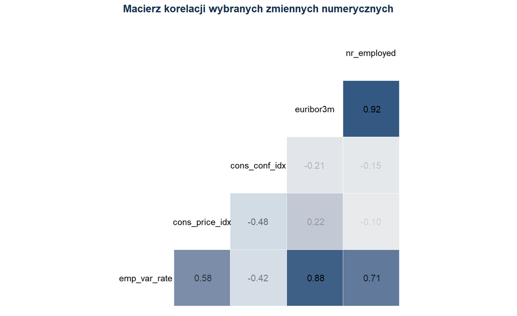

Analizujemy macierz korelacji wybranych zmiennych numerycznych, ponieważ niezasadnym jest porównywanie wieku klientów lub liczby dni, od kiedy po raz ostatni kontaktowaliśmy się z klientem, ze zmiennymi ekonomicznymi. Widzimy wysoką wartość współczynnika liniowej korelacji Pearsona dla następujących par zmiennych:

- `nr.employed` i `emp.var.rate`
- `emp.var.rate` i `euribor3m`
- `emp.var.rate` i `cons.price.idx`

Oznacza to, że wzrost wartości wskaźnika zmian zatrudnienia współwystępuje ze wzrostem wartości wskaźników inflacji, euriboru i liczby osób zatrudnionych. Tak samo sytuacja wygląda ze spadkami wartości tych zmiennych. Jeżeli ich wartości spadają, to spadają razem.

Umiarkowana ujemna wartość współczynnika korelacji Pearsona występuje dla poniższych par zmiennych:

- `cons_conf_idx` i `cons_price_idx`
- `cons_conf_idx` i `emp_var_rate`

Oznacza to, że wraz ze wzrostem wartości wskaźnika nastrojów konsumenckich spadają wartości wskaźnika zmienności zatrudnienia i wskaźnika inflacji.

Zauważmy, że dla powyższych par współczynnik korelacji Pearsona ma wartość istotną statystycznie, czego dowodem są poprzednio przeprowadzone testy statystyczne i uzyskane na ich podstawie wartości p.

## 3.2 Zależności między zmiennymi jakościowymi

Jako miarę związku między zmiennymi jakościowymi wykorzystujemy współczynnik V Cramera obliczany z poniższego wzoru:

$$V = \sqrt{\frac{\chi^2}{n(k-1)}}$$

gdzie $\chi^2$ jest statystyką chi-kwadrat obliczoną z testu chi-kwadrat, n jest liczebnością próby, k mniejszą liczbą z kategorii obu zmiennych. Wartość 0 oznacza brak związku, wartości bliskie 1 oznaczają silny związek.

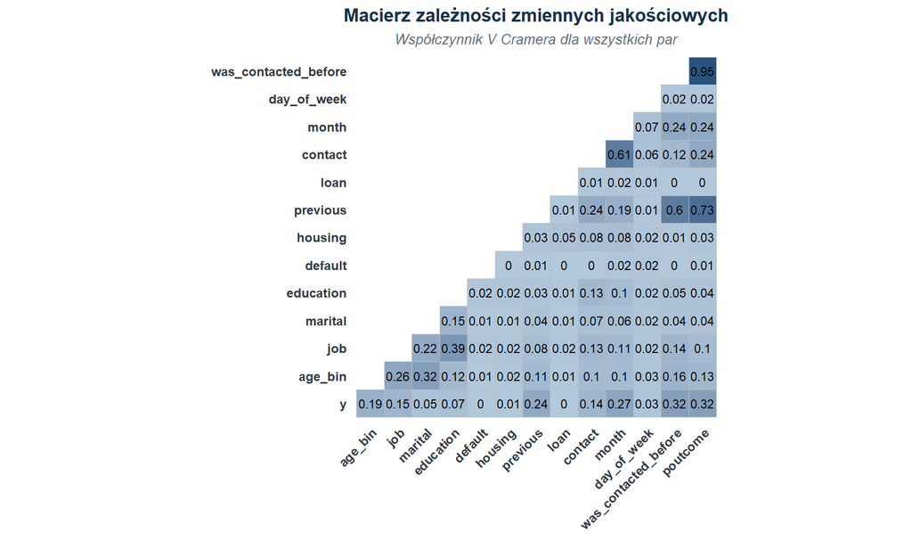

Silny związek wg tej miary występuje pomiędzy zmiennymi: `month` i `contact`, `education` i `job`. Słabszy związek widać pomiędzy zmiennymi `education` i `marital` oraz pomiędzy `job` i `marital` . `age_bin` jest naturalnie związane ze zmiennymi `job`,`marital` i `education`, a `poutcome` z `was_contacted_before` . Ze zmienną wynikową `y` najbardziej związane są `poutcome`, `was_contacted_before`, `previous` , `month`, `job`, `age_bin` oraz `contact` . A zatem możemy podejrzewać, że te zmienne mają wpływ na decyzje klienckie w sprawie założenia lokaty.

## 3.3 Success rate dla poszczególnych kategorii zmiennych jakościowych

Na poniższych wykresach widnieje success rate - czyli liczba sukcesów kampanii (pozytywnej wartości zmiennej `y`) w poszczególnych grupach zmiennych kategorycznych. Na wykresach są przedstawione szare słupki, które pokazują rzeczywistą liczebność danej grupy w zbiorze. Dzięki temu nie otrzymujemy błędnego wrażenia na temat sukcesu grupy, przeoczając jej prawdziwą liczebność. Bo jeśli obserwacji w danej grupie jest mało, to potrzebujemy mniejszą liczbę klientów, by zwiększyć poziom sukcesu dla danej grupy.

**Zawód**

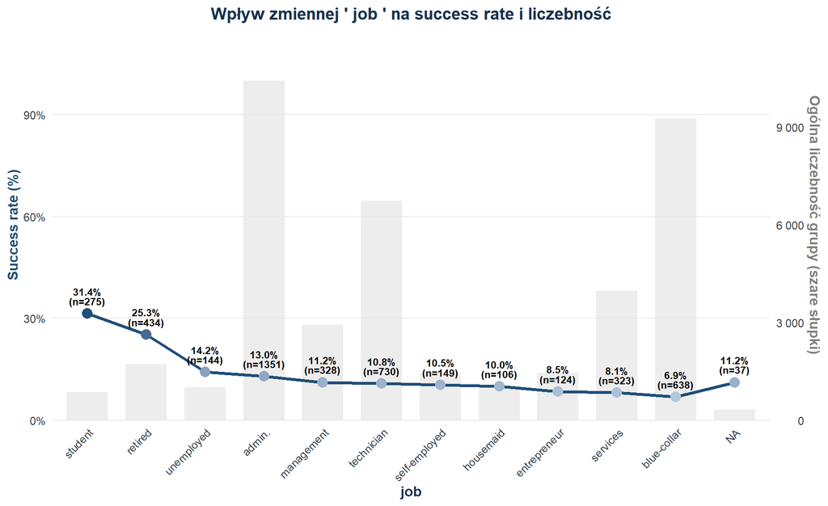

**Poprzednia kampania**

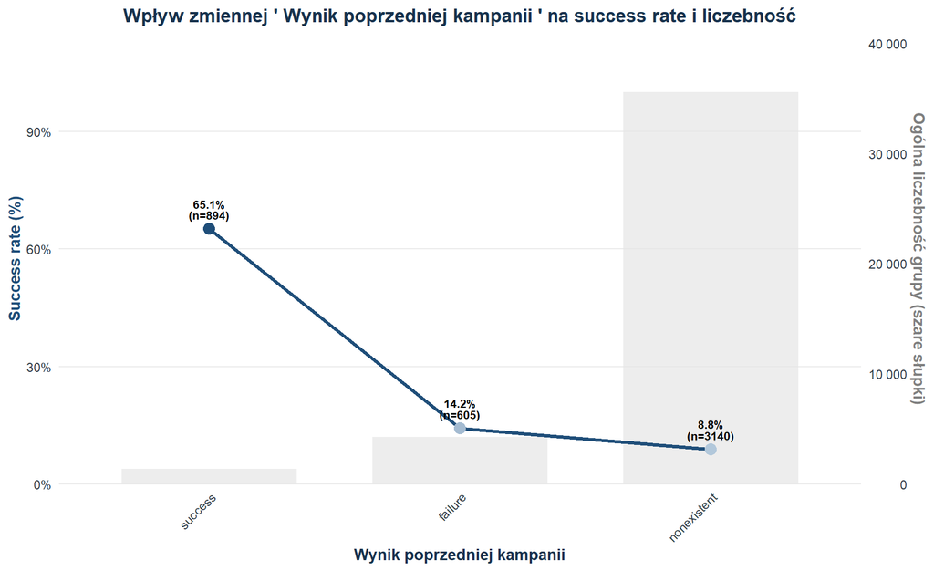

**Wiek**

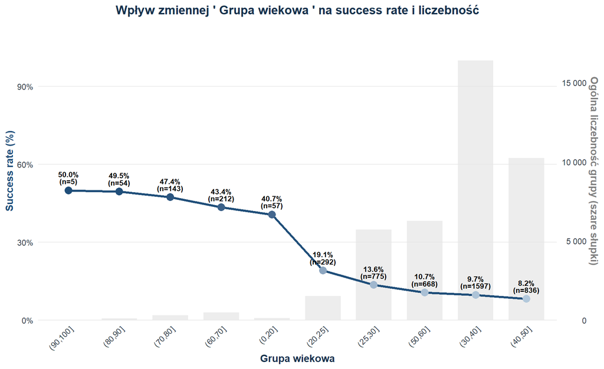

**Status**

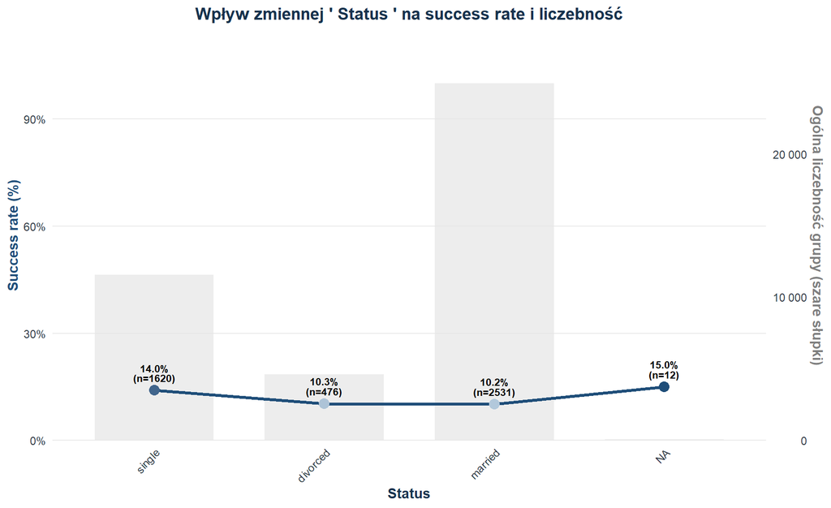

**Edukacja**

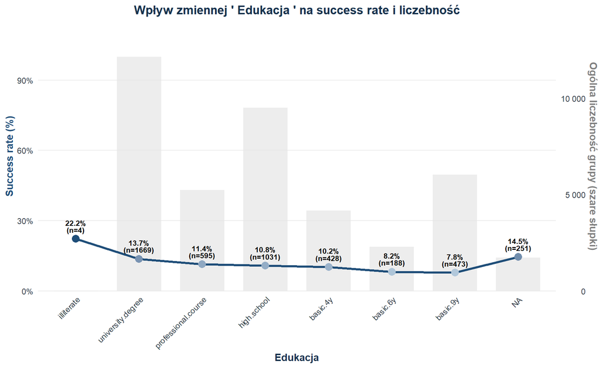

**Default**

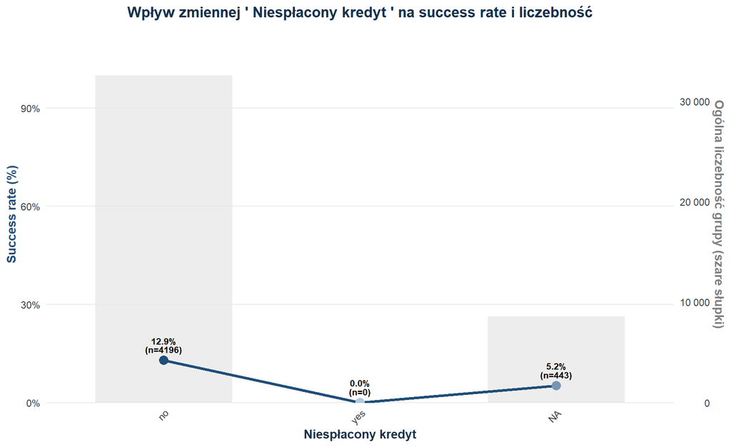

**Hipoteka**

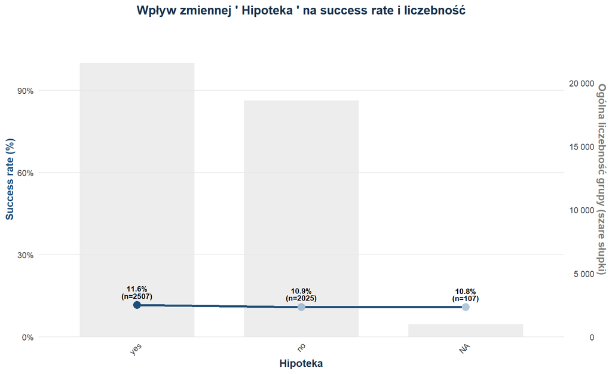

**Kredyt**

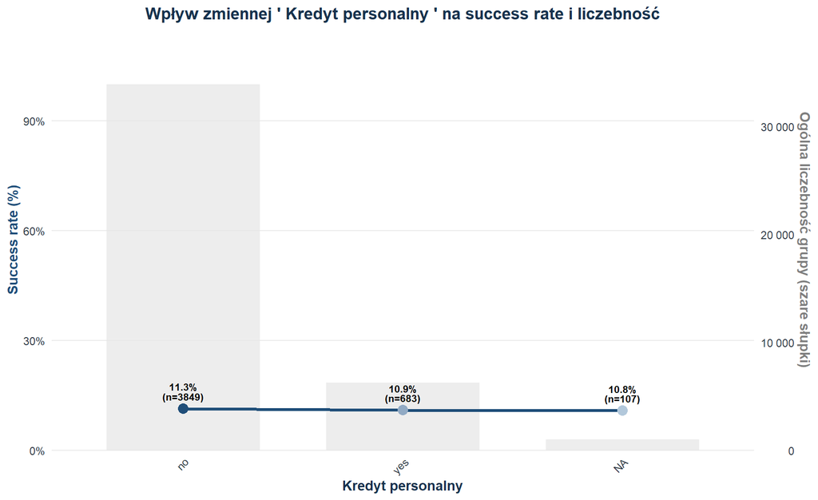

**Kontakt**

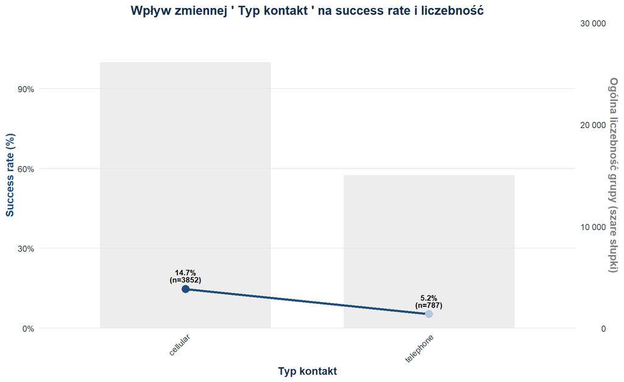

**Miesiąc**

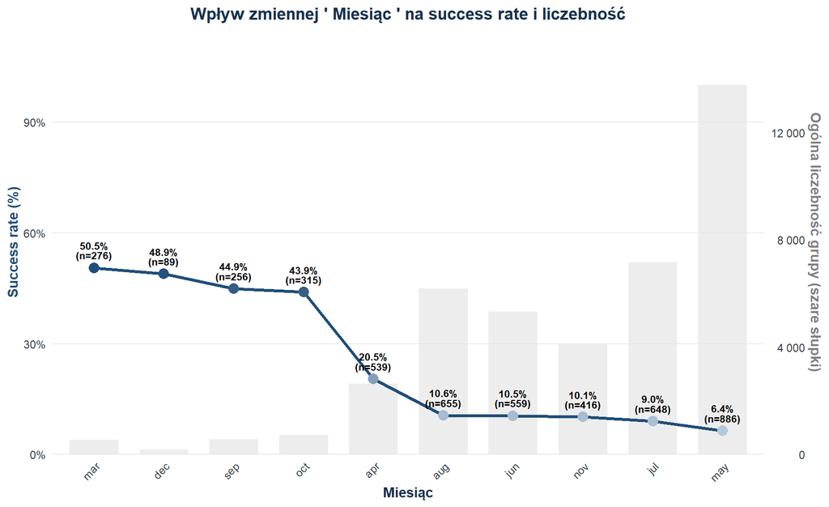

**Dzień**

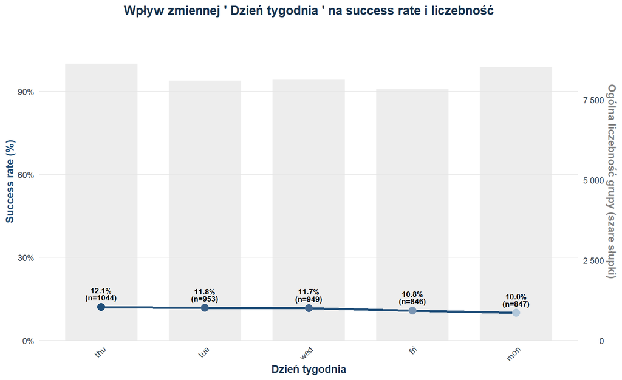

**Previous**

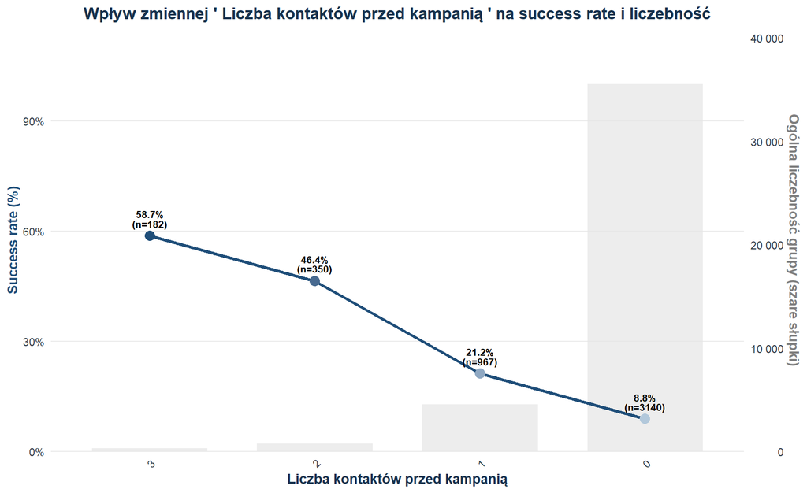

Na podstawie tych informacji w budowie dalszych modeli nie będziemy uwzględniać zmiennej `day_of_week` .